# Risk Factor Analysis

## Outcome Variable

**Outcome Variable:** ever_wasted

## Predictor Variables

**Intervention Variable:** nchldlt5

**Adjustment Set:**

- arm
- W_mage
- meducyrs
- feducyrs
- hhwealth_quart
- hfoodsec
- W_mhtcm
- W_mwtkg
- W_mbmi
- W_nrooms
- W_parity
- impfloor
- impsan
- safeh20
- delta_W_mage
- delta_meducyrs
- delta_feducyrs
- delta_hhwealth_quart
- delta_hfoodsec
- delta_W_mhtcm
- delta_W_mwtkg
- delta_W_mbmi
- delta_W_nrooms
- delta_W_parity
- delta_impfloor
- delta_impsan
- delta_safeh20

## Stratifying Variables

The analysis was stratified on these variable(s):

- agecat
- studyid
- country

## Data Summary

| agecat | studyid | country | nchldlt5 | ever_wasted | n_cell | n |
| --- | --- | --- | --- | --- | --- | --- |
| 0-24 months | iLiNS-Zinc | BURKINA FASO | 1 | 0 | 838 | 3189 |
| 0-24 months | iLiNS-Zinc | BURKINA FASO | 1 | 1 | 235 | 3189 |
| 0-24 months | iLiNS-Zinc | BURKINA FASO | 2+ | 0 | 1624 | 3189 |
| 0-24 months | iLiNS-Zinc | BURKINA FASO | 2+ | 1 | 492 | 3189 |
| 0-24 months | IRC | INDIA | 1 | 0 | 25 | 410 |
| 0-24 months | IRC | INDIA | 1 | 1 | 64 | 410 |
| 0-24 months | IRC | INDIA | 2+ | 0 | 116 | 410 |
| 0-24 months | IRC | INDIA | 2+ | 1 | 205 | 410 |
| 0-24 months | JiVitA-3 | BANGLADESH | 1 | 0 | 12739 | 26929 |
| 0-24 months | JiVitA-3 | BANGLADESH | 1 | 1 | 4485 | 26929 |
| 0-24 months | JiVitA-3 | BANGLADESH | 2+ | 0 | 7242 | 26929 |
| 0-24 months | JiVitA-3 | BANGLADESH | 2+ | 1 | 2463 | 26929 |
| 0-24 months | LCNI-5 | MALAWI | 1 | 0 | 366 | 812 |
| 0-24 months | LCNI-5 | MALAWI | 1 | 1 | 25 | 812 |
| 0-24 months | LCNI-5 | MALAWI | 2+ | 0 | 380 | 812 |
| 0-24 months | LCNI-5 | MALAWI | 2+ | 1 | 41 | 812 |
| 0-24 months | NIH-Crypto | BANGLADESH | 1 | 0 | 369 | 758 |
| 0-24 months | NIH-Crypto | BANGLADESH | 1 | 1 | 172 | 758 |
| 0-24 months | NIH-Crypto | BANGLADESH | 2+ | 0 | 139 | 758 |
| 0-24 months | NIH-Crypto | BANGLADESH | 2+ | 1 | 78 | 758 |
| 0-24 months | PROVIDE | BANGLADESH | 1 | 0 | 327 | 700 |
| 0-24 months | PROVIDE | BANGLADESH | 1 | 1 | 185 | 700 |
| 0-24 months | PROVIDE | BANGLADESH | 2+ | 0 | 127 | 700 |
| 0-24 months | PROVIDE | BANGLADESH | 2+ | 1 | 61 | 700 |
| 0-24 months | TanzaniaChild2 | TANZANIA, UNITED REPUBLIC OF | 1 | 0 | 1242 | 2385 |
| 0-24 months | TanzaniaChild2 | TANZANIA, UNITED REPUBLIC OF | 1 | 1 | 395 | 2385 |
| 0-24 months | TanzaniaChild2 | TANZANIA, UNITED REPUBLIC OF | 2+ | 0 | 579 | 2385 |
| 0-24 months | TanzaniaChild2 | TANZANIA, UNITED REPUBLIC OF | 2+ | 1 | 169 | 2385 |
| 0-6 months | IRC | INDIA | 1 | 0 | 37 | 410 |
| 0-6 months | IRC | INDIA | 1 | 1 | 52 | 410 |
| 0-6 months | IRC | INDIA | 2+ | 0 | 150 | 410 |
| 0-6 months | IRC | INDIA | 2+ | 1 | 171 | 410 |
| 0-6 months | JiVitA-3 | BANGLADESH | 1 | 0 | 14046 | 26832 |
| 0-6 months | JiVitA-3 | BANGLADESH | 1 | 1 | 3099 | 26832 |
| 0-6 months | JiVitA-3 | BANGLADESH | 2+ | 0 | 8058 | 26832 |
| 0-6 months | JiVitA-3 | BANGLADESH | 2+ | 1 | 1629 | 26832 |
| 0-6 months | LCNI-5 | MALAWI | 1 | 0 | 121 | 267 |
| 0-6 months | LCNI-5 | MALAWI | 1 | 1 | 1 | 267 |
| 0-6 months | LCNI-5 | MALAWI | 2+ | 0 | 142 | 267 |
| 0-6 months | LCNI-5 | MALAWI | 2+ | 1 | 3 | 267 |
| 0-6 months | NIH-Crypto | BANGLADESH | 1 | 0 | 405 | 758 |
| 0-6 months | NIH-Crypto | BANGLADESH | 1 | 1 | 136 | 758 |
| 0-6 months | NIH-Crypto | BANGLADESH | 2+ | 0 | 158 | 758 |
| 0-6 months | NIH-Crypto | BANGLADESH | 2+ | 1 | 59 | 758 |
| 0-6 months | PROVIDE | BANGLADESH | 1 | 0 | 375 | 700 |
| 0-6 months | PROVIDE | BANGLADESH | 1 | 1 | 137 | 700 |
| 0-6 months | PROVIDE | BANGLADESH | 2+ | 0 | 144 | 700 |
| 0-6 months | PROVIDE | BANGLADESH | 2+ | 1 | 44 | 700 |
| 0-6 months | TanzaniaChild2 | TANZANIA, UNITED REPUBLIC OF | 1 | 0 | 1407 | 2385 |
| 0-6 months | TanzaniaChild2 | TANZANIA, UNITED REPUBLIC OF | 1 | 1 | 230 | 2385 |
| 0-6 months | TanzaniaChild2 | TANZANIA, UNITED REPUBLIC OF | 2+ | 0 | 646 | 2385 |
| 0-6 months | TanzaniaChild2 | TANZANIA, UNITED REPUBLIC OF | 2+ | 1 | 102 | 2385 |
| 6-24 months | iLiNS-Zinc | BURKINA FASO | 1 | 0 | 838 | 3189 |
| 6-24 months | iLiNS-Zinc | BURKINA FASO | 1 | 1 | 235 | 3189 |
| 6-24 months | iLiNS-Zinc | BURKINA FASO | 2+ | 0 | 1624 | 3189 |
| 6-24 months | iLiNS-Zinc | BURKINA FASO | 2+ | 1 | 492 | 3189 |
| 6-24 months | IRC | INDIA | 1 | 0 | 56 | 410 |
| 6-24 months | IRC | INDIA | 1 | 1 | 33 | 410 |
| 6-24 months | IRC | INDIA | 2+ | 0 | 227 | 410 |
| 6-24 months | IRC | INDIA | 2+ | 1 | 94 | 410 |
| 6-24 months | JiVitA-3 | BANGLADESH | 1 | 0 | 9417 | 17286 |
| 6-24 months | JiVitA-3 | BANGLADESH | 1 | 1 | 1787 | 17286 |
| 6-24 months | JiVitA-3 | BANGLADESH | 2+ | 0 | 5037 | 17286 |
| 6-24 months | JiVitA-3 | BANGLADESH | 2+ | 1 | 1045 | 17286 |
| 6-24 months | LCNI-5 | MALAWI | 1 | 0 | 360 | 800 |
| 6-24 months | LCNI-5 | MALAWI | 1 | 1 | 24 | 800 |
| 6-24 months | LCNI-5 | MALAWI | 2+ | 0 | 377 | 800 |
| 6-24 months | LCNI-5 | MALAWI | 2+ | 1 | 39 | 800 |
| 6-24 months | NIH-Crypto | BANGLADESH | 1 | 0 | 460 | 730 |
| 6-24 months | NIH-Crypto | BANGLADESH | 1 | 1 | 60 | 730 |
| 6-24 months | NIH-Crypto | BANGLADESH | 2+ | 0 | 174 | 730 |
| 6-24 months | NIH-Crypto | BANGLADESH | 2+ | 1 | 36 | 730 |
| 6-24 months | PROVIDE | BANGLADESH | 1 | 0 | 380 | 615 |
| 6-24 months | PROVIDE | BANGLADESH | 1 | 1 | 68 | 615 |
| 6-24 months | PROVIDE | BANGLADESH | 2+ | 0 | 136 | 615 |
| 6-24 months | PROVIDE | BANGLADESH | 2+ | 1 | 31 | 615 |
| 6-24 months | TanzaniaChild2 | TANZANIA, UNITED REPUBLIC OF | 1 | 0 | 1154 | 2010 |
| 6-24 months | TanzaniaChild2 | TANZANIA, UNITED REPUBLIC OF | 1 | 1 | 229 | 2010 |
| 6-24 months | TanzaniaChild2 | TANZANIA, UNITED REPUBLIC OF | 2+ | 0 | 533 | 2010 |
| 6-24 months | TanzaniaChild2 | TANZANIA, UNITED REPUBLIC OF | 2+ | 1 | 94 | 2010 |

The following strata were considered:

- agecat: 0-24 months, studyid: iLiNS-Zinc, country: BURKINA FASO
- agecat: 0-24 months, studyid: IRC, country: INDIA
- agecat: 0-24 months, studyid: JiVitA-3, country: BANGLADESH
- agecat: 0-24 months, studyid: LCNI-5, country: MALAWI
- agecat: 0-24 months, studyid: NIH-Crypto, country: BANGLADESH
- agecat: 0-24 months, studyid: PROVIDE, country: BANGLADESH
- agecat: 0-24 months, studyid: TanzaniaChild2, country: TANZANIA, UNITED REPUBLIC OF
- agecat: 0-6 months, studyid: IRC, country: INDIA
- agecat: 0-6 months, studyid: JiVitA-3, country: BANGLADESH
- agecat: 0-6 months, studyid: LCNI-5, country: MALAWI
- agecat: 0-6 months, studyid: NIH-Crypto, country: BANGLADESH
- agecat: 0-6 months, studyid: PROVIDE, country: BANGLADESH
- agecat: 0-6 months, studyid: TanzaniaChild2, country: TANZANIA, UNITED REPUBLIC OF
- agecat: 6-24 months, studyid: iLiNS-Zinc, country: BURKINA FASO
- agecat: 6-24 months, studyid: IRC, country: INDIA
- agecat: 6-24 months, studyid: JiVitA-3, country: BANGLADESH
- agecat: 6-24 months, studyid: LCNI-5, country: MALAWI
- agecat: 6-24 months, studyid: NIH-Crypto, country: BANGLADESH
- agecat: 6-24 months, studyid: PROVIDE, country: BANGLADESH
- agecat: 6-24 months, studyid: TanzaniaChild2, country: TANZANIA, UNITED REPUBLIC OF

### Dropped Strata

Some strata were dropped due to rare outcomes:

- agecat: 0-6 months, studyid: LCNI-5, country: MALAWI

## Methods Detail

We’re interested in the causal parameters $E[Y_a]$ for all values of $a \in \mathcal{A}$. These parameters represent the mean outcome if, possibly contrary to fact, we intervened to set all units to have $A=a$. Under the randomization and positivity assumptions, these are identified by the statistical parameters $\psi_a=E_W[E_{Y|A,W}(Y|A=a,W)]$. In addition, we’re interested in the mean of $Y$, $E[Y]$ under no intervention (the observed mean). We will estimate these parameters by using SuperLearner to fit the relevant likelihood factors – $E_{Y|A,W}(Y|A=a,W)$ and $p(A=a|W)$, and then updating our likelihood fit using a joint TMLE.

For unadjusted analyses ($W=\{\}$), initial likelihoods were estimated using Lrnr_glm to estimate the simple $E(Y|A)$ and Lrnr_mean to estimate $p(A)$. For adjusted analyses, a small library containing Lrnr_glmnet, Lrnr_xgboost, and Lrnr_mean was used.

Having estimated these parameters, we will then use the delta method to estimate relative risks and attributable risks relative to a prespecified baseline level of $A$.

# Results Detail

## Results Plots

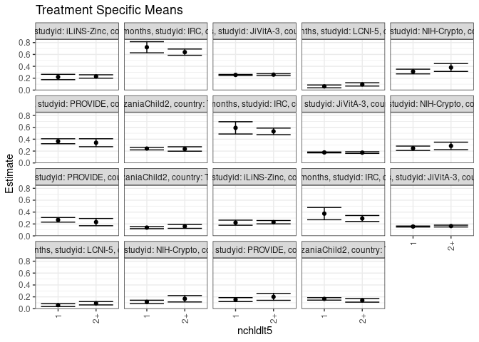

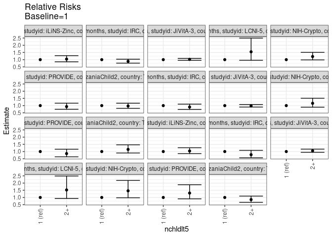

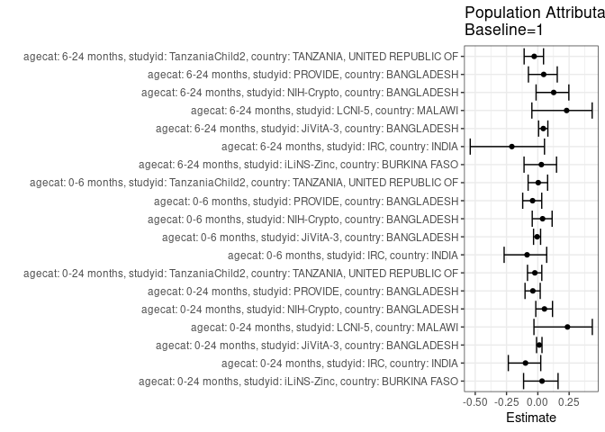

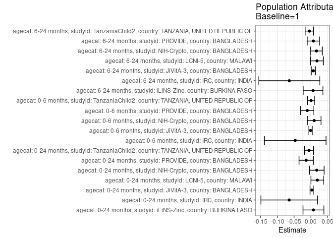

## Results Table

### Parameter: TSM

| agecat | studyid | country | intervention_level | baseline_level | estimate | ci_lower | ci_upper |
| --- | --- | --- | --- | --- | --- | --- | --- |
| 0-24 months | iLiNS-Zinc | BURKINA FASO | 1 | NA | 0.2202825 | 0.1754925 | 0.2650725 |
| 0-24 months | iLiNS-Zinc | BURKINA FASO | 2+ | NA | 0.2291344 | 0.2008211 | 0.2574477 |
| 0-24 months | IRC | INDIA | 1 | NA | 0.7207712 | 0.6273930 | 0.8141495 |
| 0-24 months | IRC | INDIA | 2+ | NA | 0.6384361 | 0.5857850 | 0.6910872 |
| 0-24 months | JiVitA-3 | BANGLADESH | 1 | NA | 0.2549759 | 0.2465977 | 0.2633542 |
| 0-24 months | JiVitA-3 | BANGLADESH | 2+ | NA | 0.2595061 | 0.2440374 | 0.2749747 |
| 0-24 months | LCNI-5 | MALAWI | 1 | NA | 0.0620216 | 0.0382791 | 0.0857641 |
| 0-24 months | LCNI-5 | MALAWI | 2+ | NA | 0.0958229 | 0.0677549 | 0.1238909 |
| 0-24 months | NIH-Crypto | BANGLADESH | 1 | NA | 0.3123864 | 0.2727620 | 0.3520108 |
| 0-24 months | NIH-Crypto | BANGLADESH | 2+ | NA | 0.3798325 | 0.3137363 | 0.4459287 |
| 0-24 months | PROVIDE | BANGLADESH | 1 | NA | 0.3654061 | 0.3236431 | 0.4071692 |
| 0-24 months | PROVIDE | BANGLADESH | 2+ | NA | 0.3406065 | 0.2735399 | 0.4076732 |
| 0-24 months | TanzaniaChild2 | TANZANIA, UNITED REPUBLIC OF | 1 | NA | 0.2421004 | 0.2199470 | 0.2642537 |
| 0-24 months | TanzaniaChild2 | TANZANIA, UNITED REPUBLIC OF | 2+ | NA | 0.2352998 | 0.1980465 | 0.2725532 |
| 0-6 months | IRC | INDIA | 1 | NA | 0.5906391 | 0.4875605 | 0.6937177 |
| 0-6 months | IRC | INDIA | 2+ | NA | 0.5317036 | 0.4767748 | 0.5866323 |
| 0-6 months | JiVitA-3 | BANGLADESH | 1 | NA | 0.1771900 | 0.1695315 | 0.1848486 |
| 0-6 months | JiVitA-3 | BANGLADESH | 2+ | NA | 0.1742959 | 0.1600986 | 0.1884933 |
| 0-6 months | NIH-Crypto | BANGLADESH | 1 | NA | 0.2474735 | 0.2106627 | 0.2842843 |
| 0-6 months | NIH-Crypto | BANGLADESH | 2+ | NA | 0.2869913 | 0.2240480 | 0.3499346 |
| 0-6 months | PROVIDE | BANGLADESH | 1 | NA | 0.2694254 | 0.2307546 | 0.3080961 |
| 0-6 months | PROVIDE | BANGLADESH | 2+ | NA | 0.2312883 | 0.1700398 | 0.2925368 |
| 0-6 months | TanzaniaChild2 | TANZANIA, UNITED REPUBLIC OF | 1 | NA | 0.1387313 | 0.1209490 | 0.1565135 |
| 0-6 months | TanzaniaChild2 | TANZANIA, UNITED REPUBLIC OF | 2+ | NA | 0.1591197 | 0.1261389 | 0.1921006 |
| 6-24 months | iLiNS-Zinc | BURKINA FASO | 1 | NA | 0.2215149 | 0.1787572 | 0.2642725 |
| 6-24 months | iLiNS-Zinc | BURKINA FASO | 2+ | NA | 0.2298760 | 0.2018132 | 0.2579387 |
| 6-24 months | IRC | INDIA | 1 | NA | 0.3740138 | 0.2705628 | 0.4774647 |
| 6-24 months | IRC | INDIA | 2+ | NA | 0.2923398 | 0.2424644 | 0.3422153 |
| 6-24 months | JiVitA-3 | BANGLADESH | 1 | NA | 0.1566489 | 0.1483381 | 0.1649597 |
| 6-24 months | JiVitA-3 | BANGLADESH | 2+ | NA | 0.1645470 | 0.1491277 | 0.1799662 |
| 6-24 months | LCNI-5 | MALAWI | 1 | NA | 0.0606360 | 0.0368760 | 0.0843959 |
| 6-24 months | LCNI-5 | MALAWI | 2+ | NA | 0.0922291 | 0.0643866 | 0.1200716 |
| 6-24 months | NIH-Crypto | BANGLADESH | 1 | NA | 0.1148500 | 0.0870181 | 0.1426820 |
| 6-24 months | NIH-Crypto | BANGLADESH | 2+ | NA | 0.1678087 | 0.1140109 | 0.2216066 |
| 6-24 months | PROVIDE | BANGLADESH | 1 | NA | 0.1534116 | 0.1201918 | 0.1866314 |
| 6-24 months | PROVIDE | BANGLADESH | 2+ | NA | 0.2003455 | 0.1416634 | 0.2590275 |
| 6-24 months | TanzaniaChild2 | TANZANIA, UNITED REPUBLIC OF | 1 | NA | 0.1653502 | 0.1445574 | 0.1861431 |
| 6-24 months | TanzaniaChild2 | TANZANIA, UNITED REPUBLIC OF | 2+ | NA | 0.1410983 | 0.1106965 | 0.1715000 |

### Parameter: E(Y)

| agecat | studyid | country | intervention_level | baseline_level | estimate | ci_lower | ci_upper |
| --- | --- | --- | --- | --- | --- | --- | --- |
| 0-24 months | iLiNS-Zinc | BURKINA FASO | NA | NA | 0.2279712 | 0.2010014 | 0.2549409 |
| 0-24 months | IRC | INDIA | NA | NA | 0.6560976 | 0.6100625 | 0.7021326 |
| 0-24 months | JiVitA-3 | BANGLADESH | NA | NA | 0.2580118 | 0.2515422 | 0.2644814 |
| 0-24 months | LCNI-5 | MALAWI | NA | NA | 0.0812808 | 0.0624736 | 0.1000879 |
| 0-24 months | NIH-Crypto | BANGLADESH | NA | NA | 0.3298153 | 0.2963239 | 0.3633067 |
| 0-24 months | PROVIDE | BANGLADESH | NA | NA | 0.3514286 | 0.3160364 | 0.3868207 |
| 0-24 months | TanzaniaChild2 | TANZANIA, UNITED REPUBLIC OF | NA | NA | 0.2364780 | 0.2194210 | 0.2535349 |
| 0-6 months | IRC | INDIA | NA | NA | 0.5439024 | 0.4956326 | 0.5921723 |
| 0-6 months | JiVitA-3 | BANGLADESH | NA | NA | 0.1762075 | 0.1705779 | 0.1818372 |
| 0-6 months | NIH-Crypto | BANGLADESH | NA | NA | 0.2572559 | 0.2261171 | 0.2883948 |
| 0-6 months | PROVIDE | BANGLADESH | NA | NA | 0.2585714 | 0.2261125 | 0.2910304 |
| 0-6 months | TanzaniaChild2 | TANZANIA, UNITED REPUBLIC OF | NA | NA | 0.1392034 | 0.1253080 | 0.1530987 |
| 6-24 months | iLiNS-Zinc | BURKINA FASO | NA | NA | 0.2279712 | 0.2010014 | 0.2549409 |
| 6-24 months | IRC | INDIA | NA | NA | 0.3097561 | 0.2649438 | 0.3545684 |
| 6-24 months | JiVitA-3 | BANGLADESH | NA | NA | 0.1638320 | 0.1577093 | 0.1699547 |
| 6-24 months | LCNI-5 | MALAWI | NA | NA | 0.0787500 | 0.0600738 | 0.0974262 |
| 6-24 months | NIH-Crypto | BANGLADESH | NA | NA | 0.1315068 | 0.1069744 | 0.1560393 |
| 6-24 months | PROVIDE | BANGLADESH | NA | NA | 0.1609756 | 0.1319065 | 0.1900447 |
| 6-24 months | TanzaniaChild2 | TANZANIA, UNITED REPUBLIC OF | NA | NA | 0.1606965 | 0.1446374 | 0.1767556 |

### Parameter: RR

| agecat | studyid | country | intervention_level | baseline_level | estimate | ci_lower | ci_upper |
| --- | --- | --- | --- | --- | --- | --- | --- |
| 0-24 months | iLiNS-Zinc | BURKINA FASO | 1 | 1 | 1.0000000 | 1.0000000 | 1.000000 |
| 0-24 months | iLiNS-Zinc | BURKINA FASO | 2+ | 1 | 1.0401843 | 0.8479408 | 1.276013 |
| 0-24 months | IRC | INDIA | 1 | 1 | 1.0000000 | 1.0000000 | 1.000000 |
| 0-24 months | IRC | INDIA | 2+ | 1 | 0.8857680 | 0.7595181 | 1.033004 |
| 0-24 months | JiVitA-3 | BANGLADESH | 1 | 1 | 1.0000000 | 1.0000000 | 1.000000 |
| 0-24 months | JiVitA-3 | BANGLADESH | 2+ | 1 | 1.0177669 | 0.9545513 | 1.085169 |
| 0-24 months | LCNI-5 | MALAWI | 1 | 1 | 1.0000000 | 1.0000000 | 1.000000 |
| 0-24 months | LCNI-5 | MALAWI | 2+ | 1 | 1.5449915 | 0.9559928 | 2.496879 |
| 0-24 months | NIH-Crypto | BANGLADESH | 1 | 1 | 1.0000000 | 1.0000000 | 1.000000 |
| 0-24 months | NIH-Crypto | BANGLADESH | 2+ | 1 | 1.2159061 | 0.9816376 | 1.506083 |
| 0-24 months | PROVIDE | BANGLADESH | 1 | 1 | 1.0000000 | 1.0000000 | 1.000000 |
| 0-24 months | PROVIDE | BANGLADESH | 2+ | 1 | 0.9321315 | 0.7439331 | 1.167940 |
| 0-24 months | TanzaniaChild2 | TANZANIA, UNITED REPUBLIC OF | 1 | 1 | 1.0000000 | 1.0000000 | 1.000000 |
| 0-24 months | TanzaniaChild2 | TANZANIA, UNITED REPUBLIC OF | 2+ | 1 | 0.9719103 | 0.8095575 | 1.166822 |
| 0-6 months | IRC | INDIA | 1 | 1 | 1.0000000 | 1.0000000 | 1.000000 |
| 0-6 months | IRC | INDIA | 2+ | 1 | 0.9002174 | 0.7348613 | 1.102781 |
| 0-6 months | JiVitA-3 | BANGLADESH | 1 | 1 | 1.0000000 | 1.0000000 | 1.000000 |
| 0-6 months | JiVitA-3 | BANGLADESH | 2+ | 1 | 0.9836666 | 0.9000975 | 1.074995 |
| 0-6 months | NIH-Crypto | BANGLADESH | 1 | 1 | 1.0000000 | 1.0000000 | 1.000000 |
| 0-6 months | NIH-Crypto | BANGLADESH | 2+ | 1 | 1.1596851 | 0.8903486 | 1.510498 |
| 0-6 months | PROVIDE | BANGLADESH | 1 | 1 | 1.0000000 | 1.0000000 | 1.000000 |
| 0-6 months | PROVIDE | BANGLADESH | 2+ | 1 | 0.8584503 | 0.6350445 | 1.160449 |
| 0-6 months | TanzaniaChild2 | TANZANIA, UNITED REPUBLIC OF | 1 | 1 | 1.0000000 | 1.0000000 | 1.000000 |
| 0-6 months | TanzaniaChild2 | TANZANIA, UNITED REPUBLIC OF | 2+ | 1 | 1.1469637 | 0.8989265 | 1.463441 |
| 6-24 months | iLiNS-Zinc | BURKINA FASO | 1 | 1 | 1.0000000 | 1.0000000 | 1.000000 |
| 6-24 months | iLiNS-Zinc | BURKINA FASO | 2+ | 1 | 1.0377451 | 0.8540617 | 1.260933 |
| 6-24 months | IRC | INDIA | 1 | 1 | 1.0000000 | 1.0000000 | 1.000000 |
| 6-24 months | IRC | INDIA | 2+ | 1 | 0.7816285 | 0.5648122 | 1.081675 |
| 6-24 months | JiVitA-3 | BANGLADESH | 1 | 1 | 1.0000000 | 1.0000000 | 1.000000 |
| 6-24 months | JiVitA-3 | BANGLADESH | 2+ | 1 | 1.0504189 | 0.9458412 | 1.166559 |
| 6-24 months | LCNI-5 | MALAWI | 1 | 1 | 1.0000000 | 1.0000000 | 1.000000 |
| 6-24 months | LCNI-5 | MALAWI | 2+ | 1 | 1.5210299 | 0.9297386 | 2.488368 |
| 6-24 months | NIH-Crypto | BANGLADESH | 1 | 1 | 1.0000000 | 1.0000000 | 1.000000 |
| 6-24 months | NIH-Crypto | BANGLADESH | 2+ | 1 | 1.4611117 | 0.9780351 | 2.182792 |
| 6-24 months | PROVIDE | BANGLADESH | 1 | 1 | 1.0000000 | 1.0000000 | 1.000000 |
| 6-24 months | PROVIDE | BANGLADESH | 2+ | 1 | 1.3059339 | 0.9062687 | 1.881852 |
| 6-24 months | TanzaniaChild2 | TANZANIA, UNITED REPUBLIC OF | 1 | 1 | 1.0000000 | 1.0000000 | 1.000000 |
| 6-24 months | TanzaniaChild2 | TANZANIA, UNITED REPUBLIC OF | 2+ | 1 | 0.8533298 | 0.6651668 | 1.094720 |

### Parameter: PAR

| agecat | studyid | country | intervention_level | baseline_level | estimate | ci_lower | ci_upper |
| --- | --- | --- | --- | --- | --- | --- | --- |
| 0-24 months | iLiNS-Zinc | BURKINA FASO | 1 | NA | 0.0076886 | -0.0234094 | 0.0387867 |
| 0-24 months | IRC | INDIA | 1 | NA | -0.0646737 | -0.1490329 | 0.0196855 |
| 0-24 months | JiVitA-3 | BANGLADESH | 1 | NA | 0.0030359 | -0.0025740 | 0.0086458 |
| 0-24 months | LCNI-5 | MALAWI | 1 | NA | 0.0192592 | 0.0001501 | 0.0383683 |
| 0-24 months | NIH-Crypto | BANGLADESH | 1 | NA | 0.0174289 | -0.0045317 | 0.0393895 |
| 0-24 months | PROVIDE | BANGLADESH | 1 | NA | -0.0139775 | -0.0352547 | 0.0072996 |
| 0-24 months | TanzaniaChild2 | TANZANIA, UNITED REPUBLIC OF | 1 | NA | -0.0056224 | -0.0191187 | 0.0078740 |
| 0-6 months | IRC | INDIA | 1 | NA | -0.0467366 | -0.1386383 | 0.0451650 |
| 0-6 months | JiVitA-3 | BANGLADESH | 1 | NA | -0.0009825 | -0.0059388 | 0.0039737 |
| 0-6 months | NIH-Crypto | BANGLADESH | 1 | NA | 0.0097825 | -0.0106183 | 0.0301832 |
| 0-6 months | PROVIDE | BANGLADESH | 1 | NA | -0.0108539 | -0.0305085 | 0.0088007 |
| 0-6 months | TanzaniaChild2 | TANZANIA, UNITED REPUBLIC OF | 1 | NA | 0.0004721 | -0.0103529 | 0.0112971 |
| 6-24 months | iLiNS-Zinc | BURKINA FASO | 1 | NA | 0.0064563 | -0.0229039 | 0.0358165 |
| 6-24 months | IRC | INDIA | 1 | NA | -0.0642577 | -0.1552083 | 0.0266930 |
| 6-24 months | JiVitA-3 | BANGLADESH | 1 | NA | 0.0071831 | 0.0011086 | 0.0132577 |
| 6-24 months | LCNI-5 | MALAWI | 1 | NA | 0.0181140 | -0.0009691 | 0.0371972 |
| 6-24 months | NIH-Crypto | BANGLADESH | 1 | NA | 0.0166568 | -0.0006804 | 0.0339940 |
| 6-24 months | PROVIDE | BANGLADESH | 1 | NA | 0.0075640 | -0.0109764 | 0.0261043 |
| 6-24 months | TanzaniaChild2 | TANZANIA, UNITED REPUBLIC OF | 1 | NA | -0.0046537 | -0.0171049 | 0.0077974 |

### Parameter: PAF

| agecat | studyid | country | intervention_level | baseline_level | estimate | ci_lower | ci_upper |
| --- | --- | --- | --- | --- | --- | --- | --- |
| 0-24 months | iLiNS-Zinc | BURKINA FASO | 1 | NA | 0.0337264 | -0.1137032 | 0.1616396 |
| 0-24 months | IRC | INDIA | 1 | NA | -0.0985733 | -0.2357014 | 0.0233375 |
| 0-24 months | JiVitA-3 | BANGLADESH | 1 | NA | 0.0117664 | -0.0102063 | 0.0332612 |
| 0-24 months | LCNI-5 | MALAWI | 1 | NA | 0.2369462 | -0.0309289 | 0.4352170 |
| 0-24 months | NIH-Crypto | BANGLADESH | 1 | NA | 0.0528445 | -0.0162357 | 0.1172288 |
| 0-24 months | PROVIDE | BANGLADESH | 1 | NA | -0.0397735 | -0.1021467 | 0.0190699 |
| 0-24 months | TanzaniaChild2 | TANZANIA, UNITED REPUBLIC OF | 1 | NA | -0.0237754 | -0.0824260 | 0.0316972 |
| 0-6 months | IRC | INDIA | 1 | NA | -0.0859284 | -0.2691023 | 0.0708075 |
| 0-6 months | JiVitA-3 | BANGLADESH | 1 | NA | -0.0055760 | -0.0340931 | 0.0221547 |
| 0-6 months | NIH-Crypto | BANGLADESH | 1 | NA | 0.0380261 | -0.0446596 | 0.1141673 |
| 0-6 months | PROVIDE | BANGLADESH | 1 | NA | -0.0419765 | -0.1207797 | 0.0312859 |
| 0-6 months | TanzaniaChild2 | TANZANIA, UNITED REPUBLIC OF | 1 | NA | 0.0033914 | -0.0774950 | 0.0782057 |
| 6-24 months | iLiNS-Zinc | BURKINA FASO | 1 | NA | 0.0283206 | -0.1100190 | 0.1494192 |
| 6-24 months | IRC | INDIA | 1 | NA | -0.2074460 | -0.5398203 | 0.0531844 |
| 6-24 months | JiVitA-3 | BANGLADESH | 1 | NA | 0.0438444 | 0.0061224 | 0.0801346 |
| 6-24 months | LCNI-5 | MALAWI | 1 | NA | 0.2300197 | -0.0475697 | 0.4340522 |
| 6-24 months | NIH-Crypto | BANGLADESH | 1 | NA | 0.1266611 | -0.0139711 | 0.2477884 |
| 6-24 months | PROVIDE | BANGLADESH | 1 | NA | 0.0469883 | -0.0750305 | 0.1551576 |
| 6-24 months | TanzaniaChild2 | TANZANIA, UNITED REPUBLIC OF | 1 | NA | -0.0289596 | -0.1093407 | 0.0455972 |